# Reading data - Solution for Lab 2

# Exercise 1

Reading the data

```r
tmp <- read.fwf("/Users/dicook/585/us.txt.gz", c(6, 4, 2, 4, rep(c(5, 1, 1,
    1), 31)), fill = T, skip = 1650000, n = 20000, colClasses = rep("character",
    128))
iowa.falls <- subset(tmp, V1 == "134142")
dim(iowa.falls)
```

```
## [1] 6402  128
```

```r
# Extract just the minimum temperatures
iowa.falls.mintemp <- subset(iowa.falls, V4 == "TMIN")
dim(iowa.falls.mintemp)
```

```
## [1] 1418  128
```

```r
iowa.falls.mintemp[1, ]
```

```
##          V1   V2 V3   V4    V5 V6 V7 V8    V9 V10 V11 V12   V13 V14 V15
## 4335 134142 1893 01 TMIN    10     I  6   -10           6   -14
##      V16   V17 V18 V19 V20   V21 V22 V23 V24   V25 V26 V27 V28   V29 V30
## 4335   6     4           6    -4           6    -9           6    -2
##      V31 V32   V33 V34 V35 V36   V37 V38 V39 V40   V41 V42 V43 V44   V45
## 4335       6    -7           6   -11           6   -20           6    -3
##      V46 V47 V48   V49 V50 V51 V52   V53 V54 V55 V56   V57 V58 V59 V60
## 4335           6   -14           6   -21           6   -10           6
##        V61 V62 V63 V64   V65 V66 V67 V68   V69 V70 V71 V72   V73 V74 V75
## 4335   -17           6   -15           6   -20           6    -8
##      V76   V77 V78 V79 V80   V81 V82 V83 V84   V85 V86 V87 V88   V89 V90
## 4335   6   -16           6    16           6    16           6     6
##      V91 V92   V93 V94 V95 V96   V97 V98 V99 V100  V101 V102 V103 V104
## 4335       6     9           6    14            6     2         I    6
##       V105 V106 V107 V108  V109 V110 V111 V112  V113 V114 V115 V116  V117
## 4335   -18              6   -19              6     0              6   -26
##      V118 V119 V120  V121 V122 V123 V124  V125 V126 V127 V128
## 4335              6    -6              6   -12              6
```

```r
# Subset the columns, and make into elemetary form
iowa.falls.mintemp <- iowa.falls.mintemp[, c(2, 3, seq(5, 128, 4))]
```

Subsetting and rearranging data

```r
library(reshape)
iowa.falls.mintemp <- melt(iowa.falls.mintemp)
colnames(iowa.falls.mintemp) <- c("year", "month", paste("d", 1:31, sep = ""))
iowa.falls.mintemp.m <- melt(iowa.falls.mintemp, id.vars = c("year", "month"))
colnames(iowa.falls.mintemp.m)[3] <- "day"
colnames(iowa.falls.mintemp.m)[4] <- "temp"
iowa.falls.mintemp.m$temp <- as.numeric(as.character(iowa.falls.mintemp.m$temp))
iowa.falls.mintemp.m$temp[iowa.falls.mintemp.m$temp == -9999] <- NA
```

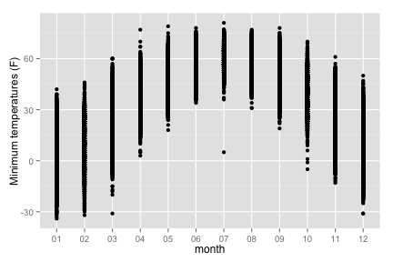

```r
# Plot the values
library(ggplot2)
qplot(month, temp, data = iowa.falls.mintemp.m, ylab = "Minimum temperatures (F)")
```

```r
# Note the strange value for one July
```

Plot description: The minimum temperature is lower in the winter months of Jan, Feb, Mar, Nov, Dec, and higher in the summer months. Lows range from -30 to 40 F in the winter, and 30 to 80 F in the summer. There is more variation in the minimum values in the winter months. There is a strange data value of about 5 F recorded one July. This has to be a mistake. It is so much lower than other values, and such a very low value that it is not believable that an event like this occurred.

Couple of comments on solutions:

- Note that there seemed to be problems trying to read the data directly off the web site. So that it was necessary to download a copy and work locally.
- Unzgip'ing and using grep to find the row numbers is a good idea - we will get to unix tools for handling large files later in the semester
- There is a data file containing just Iowa TMIN values, which is much smaller. It would be interesting to compare the values from both files. I initially started with the state data but was repeatedly getting problems with the data, errors in the values, so I switched back to the full data set.
- Some groups found the minimum of the minimum values for each month and plotted these, instead of all of the daily mins. Seasonal pattern is stronger when this is done.

# Exercise 2

```r
# Read the data from the web site
flu.data <- read.table("http://www.google.org/flutrends/us/data.txt", skip = 11,
    sep = ",", header = TRUE)
dim(flu.data)
```

```
## [1] 540 162
```

```r
flu.data[1, ]
```

```
##         Date United.States Alabama Alaska Arizona Arkansas California
## 1 2003-09-28           902     477     NA     606       NA        929
##   Colorado Connecticut Delaware District.of.Columbia Florida Georgia
## 1      233         223       NA                  927     587     514
##   Hawaii Idaho Illinois Indiana Iowa Kansas Kentucky Louisiana Maine
## 1     NA    NA      677     544  303    272      420      1017    NA
##   Maryland Massachusetts Michigan Minnesota Mississippi Missouri Montana
## 1     1268           344      685       484          NA      349      NA
##   Nebraska Nevada New.Hampshire New.Jersey New.Mexico New.York
## 1       NA     NA            NA        695         NA      649
##   North.Carolina North.Dakota Ohio Oklahoma Oregon Pennsylvania
## 1            565           NA  616     1040    409         1186
##   Rhode.Island South.Carolina South.Dakota Tennessee Texas Utah Vermont
## 1           NA            462           NA       551  1398   NA      NA
##   Virginia Washington West.Virginia Wisconsin Wyoming
## 1     1112        588            NA       466      NA
##   HHS.Region.1..CT..ME..MA..NH..RI..VT. HHS.Region.2..NJ..NY.
## 1                                   322                   666
##   HHS.Region.3..DE..DC..MD..PA..VA..WV.
## 1                                  1366
##   HHS.Region.4..AL..FL..GA..KY..MS..NC..SC..TN.
## 1                                           631
##   HHS.Region.5..IL..IN..MI..MN..OH..WI. HHS.Region.6..AR..LA..NM..OK..TX.
## 1                                   690                              1385
##   HHS.Region.7..IA..KS..MO..NE. HHS.Region.8..CO..MT..ND..SD..UT..WY.
## 1                           385                                   266
##   HHS.Region.9..AZ..CA..HI..NV. HHS.Region.10..AK..ID..OR..WA.
## 1                           878                            624
##   Anchorage..AK Birmingham..AL Little.Rock..AR Mesa..AZ Phoenix..AZ
## 1            NA            407              NA       NA         757
##   Scottsdale..AZ Tempe..AZ Tucson..AZ Berkeley..CA Fresno..CA Irvine..CA
## 1             NA       585        598           NA         NA         NA
##   Los.Angeles..CA Oakland..CA Sacramento..CA San.Diego..CA
## 1             901         848            448           562
##   San.Francisco..CA San.Jose..CA Santa.Clara..CA Sunnyvale..CA
## 1              1003          731             990           602
##   Colorado.Springs..CO Denver..CO Washington..DC Gainesville..FL
## 1                   NA        235           1153              NA
##   Hialeah..FL Jacksonville..FL Miami..FL Orlando..FL Tampa..FL Atlanta..GA
## 1          NA               NA       373         609       461         519
```

[output cut: 15 more lines]

```
## 1          437         NA               924      1034            NA
##   Eugene..OR Portland..OR Philadelphia..PA Pittsburgh..PA
## 1         NA          444             1204           1122
##   State.College..PA Providence..RI Columbia..SC Greenville..SC
## 1                NA             NA           NA             NA
##   Knoxville..TN Memphis..TN Nashville..TN Austin..TX Dallas..TX
## 1            NA          NA           425       1150       1200
##   Ft.Worth..TX Houston..TX Irving..TX Lubbock..TX Plano..TX
## 1           NA        1412       1122          NA        NA
##   San.Antonio..TX Salt.Lake.City..UT Arlington..VA Norfolk..VA Reston..VA
## 1             986                261          1066         948         NA
##   Richmond..VA Bellevue..WA Seattle..WA Spokane..WA Madison..WI
## 1         1035           NA         668          NA         622
##   Milwaukee..WI
## 1           452
```

```r
# Get only states
flu.data <- flu.data[, c(1, 3:53)]

# Melt data, and rename variables
flu.melt <- melt(flu.data, id.vars = "Date")
library(lubridate)
flu.melt$Date <- as.Date(flu.melt$Date)
colnames(flu.melt)[2] <- "State"
colnames(flu.melt)[3] <- "FluSearches"
flu.melt$Month <- month(flu.melt$Date, label = TRUE)
flu.melt$Year <- factor(year(flu.melt$Date))
flu.melt$YDay <- yday(flu.melt$Date)
head(flu.melt)
```

```
##         Date   State FluSearches Month Year YDay
## 1 2003-09-28 Alabama         477   Sep 2003  271
## 2 2003-10-05 Alabama         501   Oct 2003  278
## 3 2003-10-12 Alabama         492   Oct 2003  285
## 4 2003-10-19 Alabama         533   Oct 2003  292
## 5 2003-10-26 Alabama         594   Oct 2003  299
## 6 2003-11-02 Alabama         715   Nov 2003  306
```

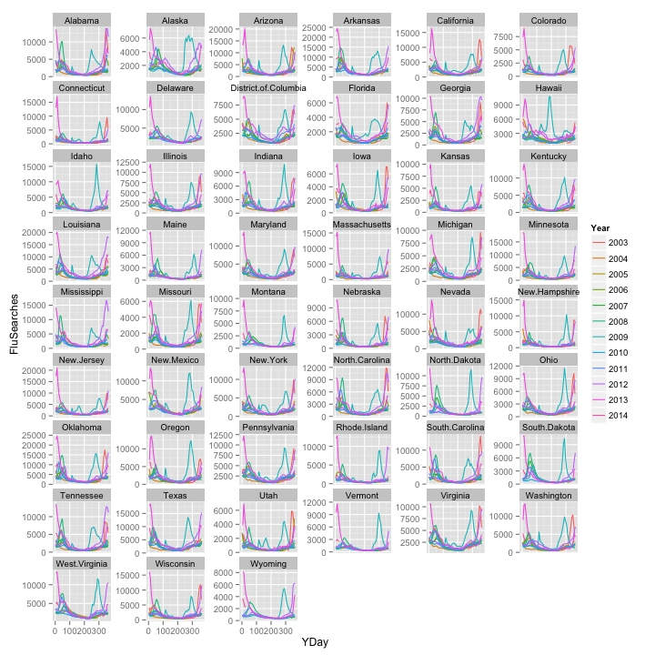

```r
# Plot data by State
qplot(YDay, FluSearches, data = flu.melt, geom = "line", group = Year, colour = Year) +
    facet_wrap(~State, ncol = 6, scales = "free_y")
```

- It is a good idea to print small chunks of the data in your solutions, just to show formatting, and structure
- To organize the states in a manner other than by alphabetical order, you need to decide on a statistic to use. Perhaps compute the day of the highest peak, and sort on this, to get states where the search peak happens at a similar time. You would need to set the factor levels of the State variable by this statistic.